# WADEPS_Tut_Pub_Classification_Beginner

2024-04-29

## Using Linear Regression to Inform Public Safety: Which counties in WA are likely to contain the least amount of crime?

Suppose you are moving to, or living in WA, and you want to ensure that the location you live in is safe. Naturally, you’d want to ensure this means it has low crime rates. Perhaps you’re specific question is, which counties in WA are predicted to have the highest crime? Knowing this can help you navigate which counties you don’t want to live in. We can answer this question using a predictive modeling technique called linear regression. Before diving into this concept, lets first upload the data and get familiar with it! For this data, a given observation depicts the counts of different crime-types in each county of WA in a given year, among other variables such as population, city police department, percent of people living in that county, etc.

## Motivating Our Question: Visualize the Data

Before diving into the answer to our question, it is important to visualize our data to identify any observed relationships between certain variables and different crime types. First lets upload the data. Since the model we are using is linear, we should see a linear relationship between inputs and output variables (i.e. a line).

```r
#install.packages("readxl") #install the required library to upload the data
library(readxl) #upload the library
#identify the path on your Excel data
directory="C:/Users/eliza/OneDrive/Documents/WADEPS/Weekly notes an ideas/Classification_SVM_Example_04_01/Flow_Chart_Data_03_30.xlsx"
data=read_excel(directory) #upload your data set
```

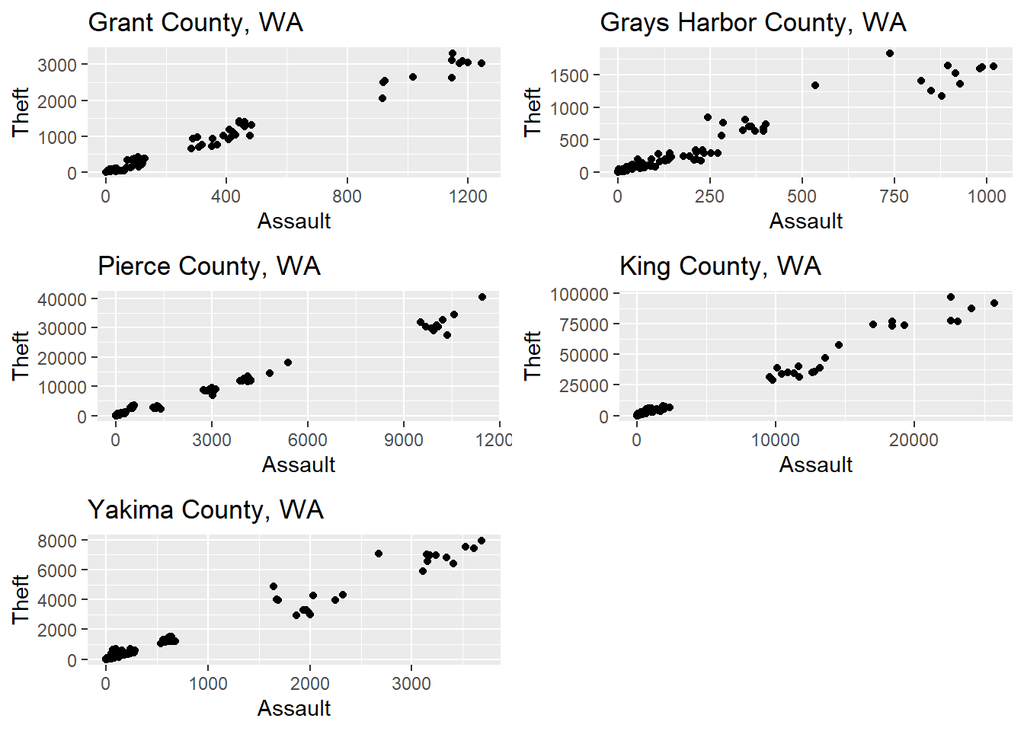

```r
library(dplyr)
library(ggplot2)
library(gridExtra)

#select Grant county data observations
GRANT=data %>%
  filter(county == "GRANT") %>%
  select(Theft, Assault)

#select Grays Harbor county data observations
GRAYSHARBOR=data %>%
  filter(county == "GRAYS HARBOR") %>%
  select(Theft, Assault)

#select Pierce county data observations
PIERCE=data %>%
  filter(county == "PIERCE") %>%
  select(Theft, Assault)

#select King county data observations
KING=data %>%
  filter(county == "KING") %>%
  select(Theft, Assault)

#select Yakima county data observations
YAKIMA=data %>%
  filter(county == "YAKIMA") %>%
  select(Theft, Assault)

#Define Grant county points
GRANTplot=ggplot(data=GRANT,aes(x=Assault,y=Theft)) +
  geom_point(pch=16) +
  ggtitle("Grant County, WA")

#Define Grays Harbor county points
GRAYSHARBORplot=ggplot(data=GRAYSHARBOR,aes(x=Assault,y=Theft)) +
  geom_point(pch=16) +
  ggtitle("Grays Harbor County, WA")

#Define Pierce county points
PIERCEplot=ggplot(data=PIERCE,aes(x=Assault,y=Theft)) +
  geom_point(pch=16) +
  ggtitle("Pierce County, WA")

#Define King county points
KINGplot=ggplot(data=KING,aes(x=Assault,y=Theft)) +
  geom_point(pch=16) +
  ggtitle("King County, WA")

#Define Yakima county points
YAKIMAplot=ggplot(data=YAKIMA,aes(x=Assault,y=Theft)) +
  geom_point(pch=16) +
  ggtitle("Yakima County, WA")

#plot all five county's information
gridExtra::grid.arrange(GRANTplot, GRAYSHARBORplot, PIERCEplot, KINGplot, YAKIMAplot, nrow = 3, ncol=2)
```

As shown, there appears to be a linear relationship between the number of thefts and the number of assaults in all five counties of WA. We now use the linear regression model function in R to fit a line to the data in all five counties. We visualize and summarize the results below for King County as an example below.

```r
#fit a line to each county model
Grantmodel=lm(Theft ~ Assault, data=GRANT)
GraysHarbormodel=lm(Theft ~ Assault, data=GRAYSHARBOR)
Piercemodel=lm(Theft ~ Assault, data=PIERCE)
Kingmodel=lm(Theft ~ Assault, data=KING)
Yakimamodel=lm(Theft ~ Assault, data=YAKIMA)
```

```r
#display results for King county model
summary(Kingmodel)
```

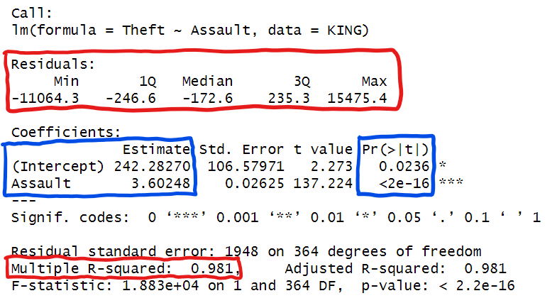

## Visualizing Our King County Model: Intercept & Slope

As a brief review, recall that lines are of the form $y=mx+b$, where $m$ is the slope of the line (change in $y$ over change in $x$), $b$ is its y-intercept ($y$ value when $x$ is 0), $x$ is an input (i.e. number of assaults in King county), and $y$ is the resulting output (i.e. number of thefts in King county). Hence, in our Kingmodel summary, we obtain an estimate of the y-intercept and slope of our model in blue above. That is, our model is of the form $y=3.60248x+242.28270$, where $x$=number of assaults in King county and $y$=number of thefts in King county. Intuitively, this means that our model predicts that when there are zero assaults in King county, there are approximately 242 thefts, and for every 1 assault the number of thefts increases by approximately 4.

The values in the $Pr(>|t|)$ blue box indicate the probability that these intercept and slope coefficients, i.e. Assault, is a not a significant predictor of theft counts in King county. These probabilities are called p-values, where small p-values (less than 0.05 typically) indicate significant predictors. Hence, in our model, Assault is a good predictor for the number of thefts in King county.

## Assessing Model Fit: How Accurate is Our Line?

Let’s now visualize our model as a red line on top of our scatterplot for King county. This is an important step, as we must ensure that our model actually fits our data reasonably well.

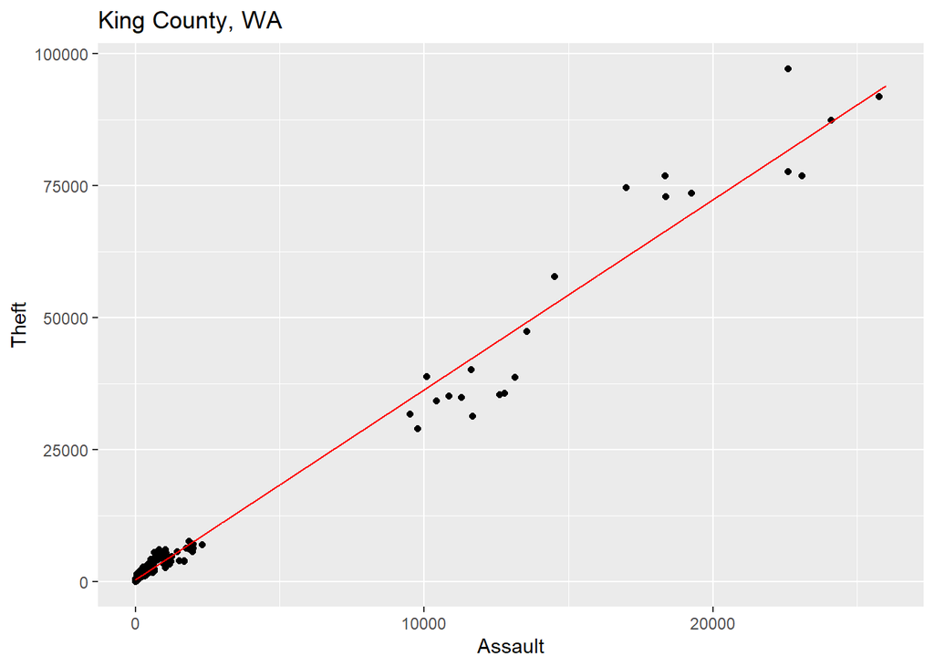

```r
#define our model for King county
  #input x: number of assaults
  #output y: predicted number of thefts
y=function(x){
  slope.estimate=3.60248
  intercept.estimate=242.28270
  return(slope.estimate*x+intercept.estimate)
}

#create data frame of inputs/outputs for our model
assaults=0:26000
thefts=y(assaults)
model=data.frame(
  x=assaults,
  y=thefts
)

#add our model to the original King county data
KINGplot_with_model=KINGplot +
  geom_line(data = model, aes(x = assaults, y = thefts), color = "red")

KINGplot_with_model
```

Other than visual inspection, there are statistical ways to assess how accurate our model is at predicting theft counts given number of assaults in King county, i.e. how well our model fits the county data. We obtain this information from the Residuals and Multiple R-squared values boxed in red in our model summary above.

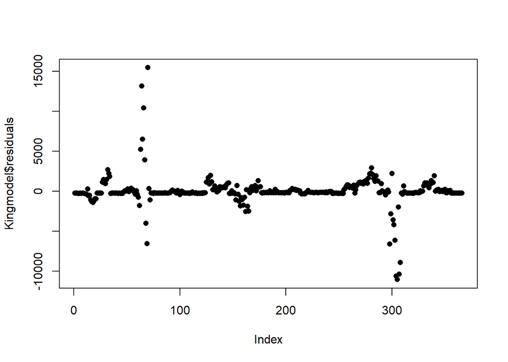

```r
plot(Kingmodel$residuals,pch=16)
```

As shown, minus a few outliers, the majority of our distances are around zero. This is indicated by our Residuals distribution information in our first red box of our Kingmodel summary.

We also use these distances to compute what’s called an R-squared value. This is a value between 0 and 1, where values close to 1 indicate good model fit and values close to 0 indicate poor model fit. As shown in our second red box in our Kingmodel summary, our R-squared value is 0.981, indicating good model fit.

## Comparing Influence of Assaults in Each County to Predicted Number of Thefts

This linear regression becomes interesting when we use it to compare the “safeness” of counties in WA. That is, we can compare the slope estimates of Assault as a predictor in each of the five counties of interest (Grant, Grays Harbor, King, Pierce, Yakima). We already computed these models, lets compare their coefficient estimates below.

```r
#obtain slope estimates for Assault in each county

Kingslope=as.data.frame(summary(Kingmodel)$coefficients[2])
colnames(Kingslope)="King"

GraysHarborslope=as.data.frame(summary(GraysHarbormodel)$coefficients[2])
colnames(GraysHarborslope)="Grays Harbor"

Grantslope=as.data.frame(summary(Grantmodel)$coefficients[2])
colnames(Grantslope)="Grant"

Pierceslope=as.data.frame(summary(Piercemodel)$coefficients[2])
colnames(Pierceslope)="Pierce"

Yakimaslope=as.data.frame(summary(Yakimamodel)$coefficients[2])
colnames(Yakimaslope)="Yakima"

#combine into a table
slopeestimates=cbind(Grantslope,GraysHarborslope,Kingslope,Pierceslope,Yakimaslope)
slopeestimates
```

```
##      Grant Grays Harbor     King   Pierce   Yakima
## 1 2.591931     1.687175 3.602482 3.081643 2.043845
```

Intuitively, our results indicate that Grays Harbor theft counts increase the least for every increase in assaults, whereas King thefts increase the most. We can visualize these in a heat map below.

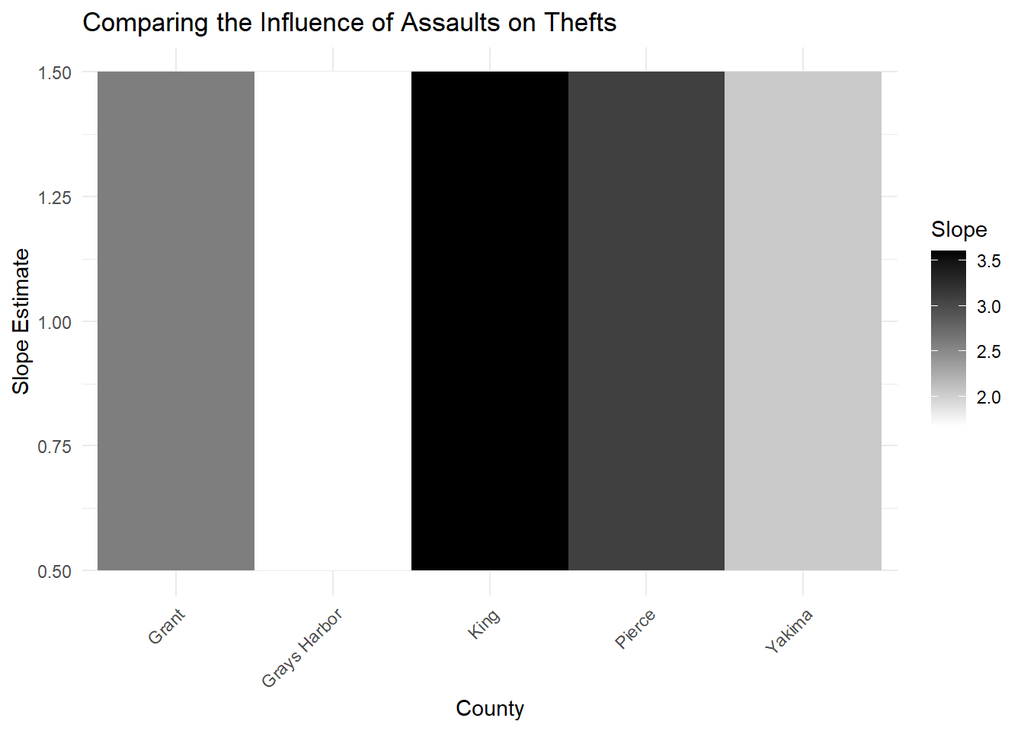

```r
slopes=as.numeric(slopeestimates[1,]) #obtain list of slope estimates
counties=c("Grant", "Grays Harbor", "King", "Pierce", "Yakima")#define counties

#create matrix for heat map
heatmap_data=data.frame(
  County=counties,
  Slope=slopes
)

#visualize heatmap
ggplot(heatmap_data, aes(x = County, y = 1, fill = Slope)) +
  geom_tile() +
  scale_fill_gradient(low = "white", high = "black") +
  labs(title = "Comparing the Influence of Assaults on Thefts", x = "County", y = "Slope Estimate") +
  theme_minimal() +
  theme(axis.text.x = element_text(angle = 45, hjust = 1))
```

As shown, the darker the color, the greater the influence that an increase in assaults has on increased theft in a given county. Based on these results in our heat map, it appears that the number of thefts in Grays Harbor increases the least given a unit increase in assaults. Hence, Grays Harbor could be the safest choice of all five counties when determining the influence that assaults in this county has on thefts. Keep in mind, that there are several other variables to explore. For instance, the population of a given county could also impact the number of thefts. This is just one example of the many methods for which we can use linear regression to inform public safety in WA.